# Introducción al R (Parte I)

Kenneth Cabrera  
martes, 21 de abril de 2015

### Breve historia

- El R es un dialecto del lenguaje S.
- El S fue desarrollado por John Chambers.
- El S fue hecho incialmente para las bibliotecas en Frotran.
- En 1988 el sistema se reescribió en C y es la base o núcleo del R actual (se denomina versión 3 del lenguaje). El libro asociado es el “libro blanco” (white book) “Statistical Models in S”.
- La versión 4 se liberó en 1998. El libro asociado es es el “libro verde” (green book) “Programming with Data” y es la versión sobre el cual R ha construido las modificaciones.

### Notas históricas del S

- En 1993 los laboratorios Bell le otorgó a StatSci (ahora la empresa se llama Insightful Corp.) una licencia para desarrollar y vender el S.
- En el 2004 Insightful le compró el lenguaje S a Lucent por dos millones de dólares y es el dueño actual.
- Insightful construyó una plataforma GUI y actualmente el producto se denomina S-PLUS, y el “PLUS” es por esta plataforma.
- En el 2009 Insightful fue comprada por TIBCO por 25 millones de dólares.

### Notas históricas del R

- 1991: Creado en Nueva Zelandia or Ross Ihaka y Robert Gentleman. Publica el artículo en 1996 en la revista JCGS (Journal of Computational and Graphical Statistics).
- 1993: Anuncio del R al público.
- 1995: Martin Mächler convenció a Ross y a Robert pasarlo a GNU.
- 1997: Se formó el grupo núcleo del R (The R Core Group). Administra el código fuente del R.
- 2000: Versión 1.0.0, 2004: Versión 2.0.0., 2013: Versión 3.0.0.
- 16 de abril de 2015: Última versión oficial liberada a la fecha 3.2.0. “Full of Ingredients”.

### Descarga del R

La versión para windows se puede descargar de este enlace: [Lenguaje estadístico R](http://cran.r-project.org/bin/windows/base/)

Es altamente recomendable integrarlo con la interfaz RStudio que se puede descargar de: [RStudio](http://www.rstudio.com/products/rstudio/download/)

### Características principales del R

- Sintaxis similar al S.
- Semántica superficialmente simila al S.
- Ejecuta casi en toda plataforma.
- Desarrollo en constate actividad.
- Útil para trabajo interactivo.
- Es libre (gratis, y abierto).

### Desventajas

- Basado en tecnología de hace 40 años.
- No soporta muy bien gráficas 3D. (Aunque tiene paquetes que manejas de manera aceptable gráficas 3D)
- La funcionalidad se base en la demanda del consumidor. Usted necesita hacer lo que otros no hacen.
- Los objetos de almacenan en memoria.
- No sirve para todo.

### Náufrago I

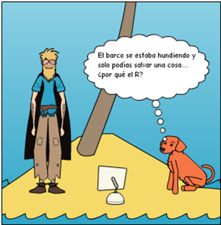

### Náufrago II

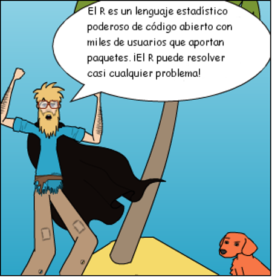

### Náufrago III

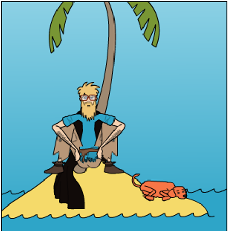

### Paquetes princiales

- El sistema básico o base el el paquete **base**.
- El sistema básico incluye paquetes como el **utils**, **stats**, **datasets**, **graphics**, **parallel** y otros.
- Paquetes recomendados **boot**, **class**, **cluster** **lattice**, **KernSmooth**, **nlme**, **nnet**, y otros.

### Paquetes adicionales

- Existen más de 5000 paquetes en el CRAN.
- Hay proyectos asociados como el Bioconductor (http://bioconductor.org).
- Algunos tienen desarrollos en su propia página por lo tanto es más difícil de seguirles el rastro.